Universidad El Bosque

Series de Tiempo

Capítulo 4 · 90–120 min (estimado)

# Modelos ARIMA y Box–Jenkins

ARIMABox–Jenkinselegir didentificar p y qmedia y derivaAICcauto.arimadiagnósticopronósticoTRM

**Javier Mauricio Sierra**

Universidad El Bosque

Series de Tiempo

Capítulo 4 · Modelos ARIMA y Box–Jenkins

Módulos 1–2 · El modelo y el método

Módulos 3–4 · Elegir d, p y q

Módulos 5–7 · Constante, estimación y auto.arima

Módulos 8–9 · Diagnóstico y pronóstico

Módulo 10 · Caso TRM, puente y cierre

Hoja de ruta

## Lo que vamos a construir hoy

Objetivo de la sesión

Tratar la diferenciación como parte del modelo y recorrer el ciclo de Box–Jenkins completo, del gráfico al pronóstico con su intervalo.

ARIMABox–Jenkinselegir didentificar p y qmedia y derivaAICcauto.arimadiagnósticopronósticoTRM

2 / 50

Modelos ARIMA y Box–Jenkins

## Cada afirmación es un dato, una definición, una interpretación o una opinión

Cada afirmación lleva su etiqueta y cada cifra, su fuente: así se distingue lo que se midió de lo que se interpreta.

| Etiqueta | Qué es |
| --- | --- |
| `Dato` | Una cifra calculada sobre una serie concreta; lleva fuente y se contrastó en R |
| `Definición` | Una verdad matemática o una convención: no depende de la serie |
| `Interpretación` | La lectura que el capítulo hace de los datos: se puede discutir |
| `Opinión` | Una recomendación o regla práctica: se defiende, no se demuestra |

[SIN VERIFICAR] marca lo que no se pudo contrastar con una fuente: no es un dato confirmado.

Fuentes: **J** = `cap4_arima.json` (R 4.6) · **R** = reejecución en R · **C** = capítulo · **D** = documentación de R · **A** = plan de auditoría

Capítulo 4 · Modelos ARIMA y Box–JenkinsSeries de Tiempo · UnBosque3 / 50

Universidad El Bosque

Series de Tiempo

Capítulo 4 · Modelos ARIMA y Box–Jenkins

Módulos 1–2 · El modelo y el método

Módulos 3–4 · Elegir d, p y q

Módulos 5–7 · Constante, estimación y auto.arima

Módulos 8–9 · Diagnóstico y pronóstico

Módulo 10 · Caso TRM, puente y cierre

01

## Módulos 1–2 · El modelo y el método

Los ARMA solo describen series estacionarias. Aquí la diferenciación deja de ser un paso previo y pasa a ser parte del modelo.

Leer en el material: De ARMA a ARIMA

4 / 50

Módulos 1–2 · El modelo y el método

## La diferenciación es parte del modelo, no un preprocesamiento

Proceso ARIMA(p,d,q)

$$\phi(B)\,(1-B)^d\,y_t = c + \theta(B)\,\varepsilon_t$$

- \(w_t=\nabla^d y_t\) sigue un ARMA(\(p,q\)) estacionario e invertible
- Son \(d\) raíces **fijadas** en \(B=1\): se imponen, no se estiman
- La **I** es de *integrated*: para volver de \(w_t\) a \(y_t\) se suma \(d\) veces

Fuente: C Módulo 1

Capítulo 4 · Modelos ARIMA y Box–JenkinsSeries de Tiempo · UnBosque5 / 50

Módulos 1–2 · El modelo y el método

## Un ARIMA(1,1,1) es un ARMA(2,1) con una raíz unitaria impuesta

$$(1-\phi B)(1-B) = 1-(1+\phi)B+\phi B^2$$

`Definición` Los coeficientes del ARMA(2,1) son \(\phi_1^{*}=1+\phi\) y \(\phi_2^{*}=-\phi\); su suma es **exactamente 1**: la firma de la raíz unitaria.

Contexto: el Nilo

`Dato` Con \(\hat\phi=0.2544\), el AR del ARIMA(1,1,1) del Nilo (Módulo 6): coeficientes **1.2544** y **−0.2544** (suma **1**); raíces de módulo **1.0000** y **3.93**. Ilustra una raíz *justo* sobre el círculo y da los pesos \(\psi\) del Módulo 9.

Fuente: J `nilo.diagnostico` (ar1) · R recalculado

Capítulo 4 · Modelos ARIMA y Box–JenkinsSeries de Tiempo · UnBosque6 / 50

Módulos 1–2 · El modelo y el método

## Suavizamiento exponencial lineal, caminata y Holt son casos particulares de ARIMA

| Modelo | Nombre | Qué dice |
| --- | --- | --- |
| ARIMA(\(p,0,q\)) | ARMA(\(p,q\)) | Todo el Capítulo 3 |
| ARIMA(\(0,1,0\)) | Caminata aleatoria | \(y_t=y_{t-1}+\varepsilon_t\): el pronóstico es el último valor |
| ARIMA(\(0,1,0\)) con \(c\) | Caminata con deriva | Añade una tendencia lineal |
| ARIMA(\(0,1,1\)) | IMA(1,1) | Equivale al suavizamiento exponencial simple, con \(\alpha=1+\theta\) (signo de R) |
| ARIMA(\(0,2,2\)) | IMA(2,2) | Incluye al método de Holt con tendencia, con restricciones sobre los coeficientes |

`Definición` Equivalencias tomadas del capítulo; el capítulo dice «equivale» para Holt, y con más precisión es un caso particular del IMA(2,2). `Interpretación` Para esos métodos no hay dos teorías, hay una: los criterios de información, el diagnóstico y los intervalos del capítulo también les sirven.

Fuente: C Módulo 1 (equivalencias no contrastadas con los libros)

Capítulo 4 · Modelos ARIMA y Box–JenkinsSeries de Tiempo · UnBosque7 / 50

Módulos 1–2 · El modelo y el método

## Tres series conducen el capítulo, y cada una enseña algo distinto

| Serie | De dónde sale | Qué ilustra |
| --- | --- | --- |
| **Nilo** · caudal anual en Asuán, 1871–1970 (*n* = 100, 10⁸ m³) | `Nile` de R; Cobb (1978) | Cómo elegir \(d\) |
| **TRM** · promedio mensual COP/USD, ene 2015–jun 2026 (*n* = 138) | Superintendencia Financiera vía datos.gov.co, consulta 2026-07-26 [SIN VERIFICAR] | El ciclo completo, de la identificación al pronóstico |
| **log(AirPassengers)** · pasajeros mensuales, 1949–1960 (*n* = 144) | `AirPassengers` de R; Box, Jenkins y Reinsel (1994) | Hasta dónde llega un ARIMA sin parte estacional |

«Qué ilustra» es `Interpretación` del capítulo. La TRM es una copia congelada: no se cotejó con datos.gov.co. Fuente: J `nilo`, `trm`, `puente_estacional` · R · D `?Nile`, `?AirPassengers`

Capítulo 4 · Modelos ARIMA y Box–JenkinsSeries de Tiempo · UnBosque8 / 50

Módulos 1–2 · El modelo y el método

## En el Nilo, diferenciar una vez casi no reduce la varianza

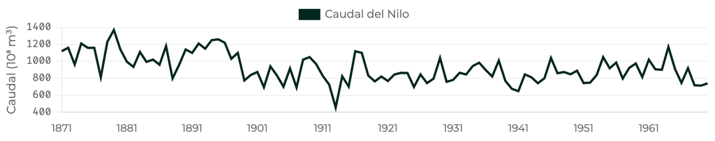

Nilo: caudal anual en Asuán, 1871–1970 (10⁸ m³). Simulador del Módulo 1

| \(d\) | \(n\) | Media | Varianza | \(\hat\rho_1\) |
| --- | --- | --- | --- | --- |
| 0 | 100 | 919.35 | 28 638 | +0.50 |
| 1 | 99 | −3.84 | 28 268 | −0.40 |
| 2 | 98 | −0.14 | 80 055 | −0.63 |

`Dato` La varianza baja solo un 1.3 % con \(d=1\) y casi se triplica con \(d=2\). `Interpretación` ¿Hacía falta diferenciar? Los Módulos 3 y 8 lo responden.

Contexto: `Nile` (R); diferenciar gana poco si el problema es un escalón (~1899). Fuente: J `nilo.varianzas`, `nilo.identificacion` · R

Capítulo 4 · Modelos ARIMA y Box–JenkinsSeries de Tiempo · UnBosque9 / 50

Módulos 1–2 · El modelo y el método

## La aportación de Box y Jenkins fue el método: un ciclo con vueltas atrás

1Identificación¿qué orden proponer?

→

2Estimación¿cuánto valen los coeficientes?

→

3Diagnóstico¿sobra estructura?

→

4Usopronosticar y explicar

Las etapas 2, 3 y 4 pueden mandar de vuelta a la identificación.

`Interpretación` La familia ya existía; la aportación fue una secuencia de etapas con criterios explícitos y vueltas atrás.

`Dato` *Time Series Analysis: Forecasting and Control*, de Box y Jenkins, 1970 (1.ª edición; la revisada es de 1976)

Fuente: C Módulo 2 · D `?BJsales` cita la edición de 1976 · Shumway y Stoffer, *Time Series Analysis and Its Applications*, cita la de 1970

Capítulo 4 · Modelos ARIMA y Box–JenkinsSeries de Tiempo · UnBosque10 / 50

Módulos 1–2 · El modelo y el método

## Cada etapa tiene un hallazgo que la obliga a devolverse

| Etapa | Qué se hace | Qué obliga a volver |
| --- | --- | --- |
| **1 · Identificación** | \(d\) primero; luego \(p\) y \(q\) en la ACF/PACF de la serie **ya diferenciada** | Residuales con estructura: el orden se quedó corto |
| **2 · Estimación** | Máxima verosimilitud; AICc y BIC dentro del mismo \(d\); revisar raíces | Sin convergencia o error estándar enorme; raíz MA sobre el círculo (bajar \(d\)) o AR (subirlo) |
| **3 · Diagnóstico** | Residuales como ruido blanco: correlograma, Ljung–Box con `fitdf = p + q` | Rechazo, o patrón en múltiplos del período: modelo estacional (Cap. 5) |
| **4 · Uso** | Pronosticar con intervalos | Forma absurda del pronóstico: \(d\) mal elegido |

`Interpretación` Reglas de lectura del capítulo.

Fuente: C Módulo 2

Capítulo 4 · Modelos ARIMA y Box–JenkinsSeries de Tiempo · UnBosque11 / 50

Pregunta para la clase

## Si el modelo estimado tiene una raíz MA de módulo 1, ¿se sube o se baja \(d\)?

Se estimó un ARIMA(0,1,1) y, en la etapa 2, el polinomio MA tiene una raíz sobre el círculo unitario. Usa la tabla anterior: ¿a qué etapa se vuelve y qué se hace con \(d\)?

Se baja \(d\)

`Interpretación` Una raíz MA sobre el círculo unitario es la firma de haber diferenciado de más: el MA intenta cancelar el factor \((1-B)\) que se añadió. Si la raíz sobre el círculo fuera la del AR, la lectura sería la contraria: se sube \(d\). Se vuelve de la estimación a la identificación.

Contexto: pregunta sobre el ciclo de Box–Jenkins; el caso completo con datos llega en el Módulo 8. Fuente: C Módulo 2

Capítulo 4 · Modelos ARIMA y Box–JenkinsSeries de Tiempo · UnBosque12 / 50

Módulos 1–2 · El modelo y el método

## El ciclo completo cabe en un esqueleto corto de R

Nilo, ciclo de Box–Jenkins

```
library(forecast)
d <- ndiffs(Nile)                  # etapa 1
ajuste <- arima(Nile, order = c(1, d, 1),
                method = "ML")     # etapa 2
res <- residuals(ajuste)           # etapa 3
Box.test(res, lag = 20, type = "Ljung-Box", fitdf = 2)$p.value
#> [1] 0.7997371
pron <- forecast(ajuste, h = 10)   # etapa 4
round(as.numeric(pron$mean[1:3]), 2)
#> [1] 816.18 835.56 840.49
```

- `Dato` Ljung–Box(20): \(p=0.800\)
- `Interpretación` \(p>0.05\): no hay evidencia de estructura sobrante
- `Dato` Pronóstico a 1, 2 y 3 años: **816.18**, **835.56** y **840.49** (10⁸ m³)

Contexto: `Nile` (R); muestra las cuatro etapas sobre una sola serie. Fuente: R código ejecutado · J `nilo.diagnostico` · C Módulo 2

Capítulo 4 · Modelos ARIMA y Box–JenkinsSeries de Tiempo · UnBosque13 / 50

Universidad El Bosque

Series de Tiempo

Capítulo 4 · Modelos ARIMA y Box–Jenkins

Módulos 1–2 · El modelo y el método

Módulos 3–4 · Elegir d, p y q

Módulos 5–7 · Constante, estimación y auto.arima

Módulos 8–9 · Diagnóstico y pronóstico

Módulo 10 · Caso TRM, puente y cierre

02

## Módulos 3–4 · Elegir d, p y q

Todo lo demás cuelga de \(d\). Tres evidencias para decidirlo, y una prueba que puede engañar.

Leer en el material: Elegir el orden d

14 / 50

Módulos 3–4 · Elegir d, p y q

## Tres evidencias miran la serie desde ángulos distintos

| Evidencia | Qué mirar | Qué dice el Nilo |
| --- | --- | --- |
| **1. El gráfico** | ¿El nivel vaga sin volver? ¿Hay saltos? | Un descenso brusco hacia 1899 |
| **2. La varianza** | \(\operatorname{Var}(\nabla^d y)\) baja y luego sube | 28 638 → 28 268 → 80 055 → 262 507: mínimo en \(d=1\) |
| **3. Las pruebas** | ADF y PP (\(H_0\): raíz unitaria); KPSS (\(H_0\): estacionaria) | ADF −3.366 (\(p=0.064\)), KPSS 0.965 (\(p<0.01\)), PP −6.690 (\(p<0.01\)) |

`Dato` ADF y KPSS apuntan a diferenciar; PP rechaza la raíz unitaria. `Interpretación` Las tres no coinciden.

Contexto: el Nilo, el caso donde las pruebas discrepan. ADF de `adf.test`: constante y tendencia, \(k=4\). Fuente: J `nilo.varianzas`, `nilo.pruebas` · R recalculado

Capítulo 4 · Modelos ARIMA y Box–JenkinsSeries de Tiempo · UnBosque15 / 50

Módulos 3–4 · Elegir d, p y q

## Las tres versiones de `ndiffs` no coinciden en el Nilo

ndiffs según la prueba

```
library(forecast)
sapply(c("kpss", "adf", "pp"),
       function(t) ndiffs(Nile, test = t))
#> kpss  adf   pp
#>    1    0    0
```

- `Dato` El valor por defecto de `ndiffs()` —el de `auto.arima()`— es KPSS: la única que dice **1**
- `Dato` El ADF de `ndiffs` usa solo constante y un rezago: \(\tau_\mu=-4.05\) frente a \(-2.89\) (5 %), rechaza. El de `adf.test`, con tendencia y \(k=4\), no
- `Interpretación` No es un fallo de ninguna función: KPSS invierte la hipótesis nula, y con un MA fuerte y negativo el PP rechaza casi siempre, aun con raíz unitaria

Comparar salidas entre programas

`tseries::kpss.test` da 0.9654; `statsmodels.kpss`, con su opción por defecto, 0.8691; con `nlags="legacy"`, 0.5497. Es el truncamiento de la varianza de largo plazo, no un error.

Contexto: el Nilo; ilustra que `ndiffs` depende de la prueba y de su especificación. Fuente: J `nilo.pruebas` · R código ejecutado · R statsmodels 0.14.6

Capítulo 4 · Modelos ARIMA y Box–JenkinsSeries de Tiempo · UnBosque16 / 50

Pregunta para la clase

## Ruido blanco puro con un escalón en 1899: ¿con qué frecuencia rechaza KPSS?

**1 000 series** de ruido blanco (\(n=100\), \(\sigma=127.03\)) con un escalón en la posición 29: **ninguna tiene raíz unitaria.**

Respuesta

`Dato` Sin escalón: **4.8 %**, cerca del 5 % nominal. Con el escalón del Nilo (\(\lvert\beta\rvert=247.8\), 1.95 desviaciones típicas): **100 %**. Con \(\lvert\beta\rvert=100\) (0.79 desviaciones): **70.8 %**.

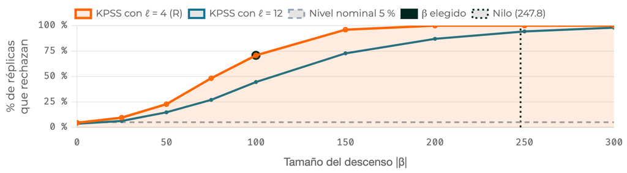

Tasa de rechazo de KPSS al 5 % según el tamaño del escalón (400 réplicas por punto). Simulador del Módulo 3 (escalón de tamaño 100)

Contexto: experimento del Módulo 3 (residuales del Nilo + escalón); ilustra que KPSS rechaza sin raíz unitaria. 4.8 % y 100 %: 1 000 réplicas; 70.8 %: malla de 400. Fuente: J `nilo.cambio_nivel` · R

Capítulo 4 · Modelos ARIMA y Box–JenkinsSeries de Tiempo · UnBosque17 / 50

Interpretación

## KPSS no distingue una raíz unitaria de un cambio de nivel

El error está en leer su rechazo como «hay que diferenciar». `Dato` El ADF de `adf.test` tampoco se salva: no rechaza la raíz unitaria en el **86.4 %** de las réplicas con escalón, frente al **5.4 %** sin él.

Contexto: mismo experimento del Módulo 3; por ahora \(d=1\) (el de KPSS) es una decisión **provisional** que el Módulo 8 pone a prueba. Fuente: J `nilo.cambio_nivel.monte_carlo` · R

Capítulo 4 · Modelos ARIMA y Box–JenkinsSeries de Tiempo · UnBosque18 / 50

Pregunta para la clase

## La ACF del Nilo sin diferenciar decae despacio: ¿qué se concluye sobre p y q?

Los primeros rezagos de la ACF son **0.498**, **0.385**, **0.328** y **0.239**, y no cortan (banda ±0.196, con \(n=100\)).

Nada todavía

`Interpretación` Esa forma es compatible con una serie no estacionaria o con un escalón: la tabla de identificación presupone estacionariedad. Leerla como un AR(1) con \(\phi\approx0.5\) es el error de principiante más caro: ese AR(1) daría 0.25 y 0.125 en los rezagos 2 y 3, no 0.385 y 0.328.

Contexto: el Nilo sin diferenciar, para ver por qué \(p\) y \(q\) se leen sobre la serie ya diferenciada. Fuente: J `nilo.identificacion.cruda` · R recalculado

Capítulo 4 · Modelos ARIMA y Box–JenkinsSeries de Tiempo · UnBosque19 / 50

Módulos 3–4 · Elegir d, p y q

## Sobre ∇Nilo la ACF corta en 1 y la PACF decae: la firma de un MA(1)

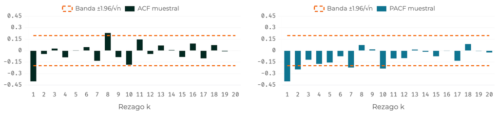

ACF (izquierda) y PACF (derecha) de ∇Nilo con la banda ±1.96/√n. Simulador del Módulo 4, \(d=1\)

- `Dato` Banda ±0.197 (\(n=99\)). ACF: salen el rezago 1 (−0.402) y el 8 (0.231). PACF: salen el 1, el 2, el 7 y el 10, todos negativos
- `Interpretación` La ACF corta en 1 y la PACF no corta: decae con signo negativo, como en un MA(1). El rezago 8 es aislado y sin patrón: con 20 rezagos al 5 %, uno fuera es lo esperable

Contexto: el Nilo diferenciado una vez; ilustra la firma de un MA(1) en la ACF y la PACF. Fuente: J `nilo.identificacion.d1` · R

Capítulo 4 · Modelos ARIMA y Box–JenkinsSeries de Tiempo · UnBosque20 / 50

Módulos 3–4 · Elegir d, p y q

## La tabla propone un ARIMA(0,1,1), pero se llevan varios candidatos, no uno

|  | ACF | PACF | Sugiere |
| --- | --- | --- | --- |
| AR(\(p\)) | decae | corta en \(p\) | ARIMA(\(p,d,0\)) |
| MA(\(q\)) | **corta en \(q\)** | **decae** | ARIMA(\(0,d,q\)) |
| ARMA(\(p,q\)) | decae | decae | hay que probar |
| **∇Nilo** | corta en 1 (−0.402) | decae | **ARIMA(\(0,1,1\))** |

- `Dato` \(\hat\theta=-0.7329\) (e.e. 0.1143, \(t=-6.41\)); Ljung–Box(20): \(p=0.674\). El AICc prefiere el (1,1,1) por 1.71 puntos (menos de 2: no distingue); el BIC, el (0,1,1)
- `Opinión` Llevar a la estimación el candidato de la tabla y sus vecinos: (0,1,1), (1,1,1), (0,1,2) y (1,1,0)

Contexto: el Nilo; ilustra cómo se aplica la tabla de identificación del Capítulo 3. Fuente: J `nilo.rejilla` · R

Capítulo 4 · Modelos ARIMA y Box–JenkinsSeries de Tiempo · UnBosque21 / 50

Universidad El Bosque

Series de Tiempo

Capítulo 4 · Modelos ARIMA y Box–Jenkins

Módulos 1–2 · El modelo y el método

Módulos 3–4 · Elegir d, p y q

Módulos 5–7 · Constante, estimación y auto.arima

Módulos 8–9 · Diagnóstico y pronóstico

Módulo 10 · Caso TRM, puente y cierre

03

## Módulos 5–7 · Constante, estimación y auto.arima

Con \(d\) y los candidatos decididos quedan tres cosas: qué significa la constante, con qué criterio comparar y qué hace `auto.arima` por ti.

Leer en el material: La constante: media y deriva

22 / 50

Módulos 5–7 · Constante, estimación y auto.arima

## La constante \(c\) significa cosas distintas según \(d\)

Qué es c en cada caso

$$\mu_w=\operatorname{E}\!\left[(1-B)^d y_t\right]=\frac{c}{\phi(1)}$$

- \(d=0\): la **media** de la serie (R la llama `intercept`)
- \(d=1\): el incremento medio por período, una tendencia lineal: la **deriva** (*drift*)
- \(d=2\): una aceleración media, una tendencia cuadrática

Cada diferencia sube en un grado el polinomio de tendencia que genera la constante. `Opinión` Con \(d=2\) «prácticamente nunca se quiere».

Fuente: C Módulo 5

Capítulo 4 · Modelos ARIMA y Box–JenkinsSeries de Tiempo · UnBosque23 / 50

Módulos 5–7 · Constante, estimación y auto.arima

## Cada programa trata la constante a su manera

| Función | Por defecto | Con \(d\ge1\) |
| --- | --- | --- |
| `stats::arima` | `include.mean = TRUE` | Se ignora en silencio: no hay constante |
| `forecast::Arima` | `include.mean = TRUE` (con \(d=0\)); `include.drift = FALSE` | Con \(d\ge2\) avisa y no la ajusta |
| `forecast::auto.arima` | Prueba con y sin deriva si \(d=1\) | Con \(d\ge2\) nunca la incluye |
| `statsmodels` ARIMA | `trend="c"` si \(d=0\), `"n"` si \(d>0\) | `trend="t"` da deriva con \(d=1\); con \(d\ge2\), `ValueError` |

`Dato` Comportamiento comprobado en R 4.3.3 (forecast 8.21.1) y statsmodels 0.14.6. `Opinión` Si un `arima()` y un `auto.arima()` no coinciden, lo primero que hay que mirar no son los órdenes sino si uno lleva deriva y el otro no.

Contexto: probado sobre el Nilo; ilustra por qué dos programas dan modelos distintos con el mismo orden. Fuente: R ejecutado · C Módulo 5 (cita R 4.6, forecast 9.0.2)

Capítulo 4 · Modelos ARIMA y Box–JenkinsSeries de Tiempo · UnBosque24 / 50

Módulos 5–7 · Constante, estimación y auto.arima

## El Nilo no lleva deriva: no es significativa y el AICc empeora

| Serie | \(\hat\delta\) | e.e. | \(t\) | AICc con deriva | AICc sin deriva |
| --- | --- | --- | --- | --- | --- |
| **Nilo**, ARIMA(1,1,1) | −2.883 | 2.017 | −1.43 | 1268.06 | 1267.51 |
| **TRM**, ARIMA(0,1,0) | 8.00 pesos/mes | 10.36 | 0.77 | 1707.41 | 1705.94 |

- `Dato` Media de las diferencias del Nilo: \((740-1120)/99=-3.84\). Solo cuentan el primer y el último año
- `Interpretación` Si el escalón de 247.8 fuera la única caída, aportaría \(-2.50\) a esa media; con \(d=1\), un cambio de nivel único solo entra como choque o repartido en pendiente
- `Opinión` Una deriva estimada es una tendencia que se extrapola sin límite: conviene no afirmarla a la ligera

Contexto: dos series con una tendencia que «se ve» y no es significativa. Fuente: J `nilo.formas_pronostico`, `trm.deriva` · R recalculado

Capítulo 4 · Modelos ARIMA y Box–JenkinsSeries de Tiempo · UnBosque25 / 50

Módulos 5–7 · Constante, estimación y auto.arima

## El AICc solo compara modelos con el mismo d

$$\begin{aligned}\mathrm{AIC}&=-2\log L+2k, \qquad \mathrm{BIC}=-2\log L+k\log n^{*}\\ \mathrm{AICc}&=\mathrm{AIC}+\frac{2k(k+1)}{n^{*}-k-1}\end{aligned}$$

`Definición` Con \(k=p+q+1\) (más uno si hay constante o deriva) y \(n^{*}=n-d\) el **número efectivo** de observaciones.

Atención

La verosimilitud de un ARIMA con \(d=1\) se calcula sobre las **99** diferencias del Nilo; la de uno con \(d=2\), sobre **98** segundas diferencias. Son datos distintos: un AICc menor con más diferencias no es un modelo mejor.

Contexto: el Nilo (\(n=100\)); ilustra cómo baja \(n^{*}\) con \(d\). Fuente: J `nilo.varianzas` (`n_efectivo`) · C Módulo 6

Capítulo 4 · Modelos ARIMA y Box–JenkinsSeries de Tiempo · UnBosque26 / 50

Pregunta para la clase

## AICc 1267.51 con un ARIMA(1,1,1) y 1264.60 con un ARIMA(1,2,2): ¿cuál eliges?

Sobre la misma serie de \(n=100\).

Ninguno, por esta comparación

`Interpretación` No son comparables: el primero se calcula sobre 99 observaciones efectivas y el segundo sobre 98. Además, el ARIMA(1,2,2) tiene una raíz MA en **1.03**, casi sobre el círculo unitario. Para decidir entre distintos \(d\): pruebas de raíz unitaria, gráfico o evaluación fuera de muestra.

Contexto: son los mejores de \(d=1\) y \(d=2\) en la rejilla de 27 modelos del Nilo; ilustran la trampa central del AICc. Fuente: J `nilo.mejor_por_d`, `nilo.rejilla` · R

Capítulo 4 · Modelos ARIMA y Box–JenkinsSeries de Tiempo · UnBosque27 / 50

Módulos 5–7 · Constante, estimación y auto.arima

## Cada d se compara solo consigo mismo: el mínimo global es una trampa

| \(d\) | \(n^*\) | Mejor por AICc | Mejor por BIC |
| --- | --- | --- | --- |
| 0 | 100 | ARIMA(1,0,1) — 1282.50 | ARIMA(1,0,1) — 1292.50 |
| 1 | 99 | ARIMA(1,1,1) — 1267.51 | ARIMA(0,1,1) — 1274.28 |
| 2 | 98 | ARIMA(1,2,2) — 1264.60 | ARIMA(0,2,2) — 1273.50 |

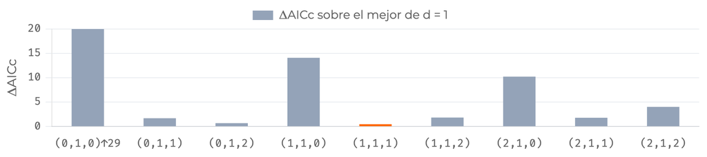

ΔAICc sobre el mejor de d = 1: cuatro modelos a menos de 2 puntos. Simulador del Módulo 6

- `Dato` El ARIMA(0,2,2), mejor por BIC con \(d=2\), tiene \(\lvert\text{raíz MA}\rvert=1.000\): no es invertible

Contexto: los 27 modelos del Nilo, \(p,d,q\in\{0,1,2\}\). Fuente: J `nilo.mejor_por_d`, `nilo.rejilla` · R

Capítulo 4 · Modelos ARIMA y Box–JenkinsSeries de Tiempo · UnBosque28 / 50

Módulos 5–7 · Constante, estimación y auto.arima

## `auto.arima` es un algoritmo con reglas explícitas, no una caja negra

1Elegir \(d\)con pruebas KPSS sucesivas: se diferencia mientras KPSS rechace la estacionariedad

→

2Ajustar modelos iniciales(2,\(d\),2), (0,\(d\),0), (1,\(d\),0) y (0,\(d\),1), con constante si \(d\le1\), y (0,\(d\),0) sin constante

→

3Buscar en el vecindario\(p\) y \(q\) en ±1, con o sin constante; lo que mejora el AICc reinicia la búsqueda

→

4Pararcuando ninguna variante mejora

`Dato` Los ajustes con alguna raíz ARMA de módulo < 1.01 se descartan (su criterio de selección pasa a ∞). En el Nilo, el ARIMA(2,1,2) ajustado con `Arima()` tiene una raíz AR de módulo **≈ 1.001**. La búsqueda escalonada evalúa **18** modelos; la exhaustiva, **42**.

Contexto: el algoritmo de Hyndman y Khandakar (2008), sobre el Nilo. Fuente: C Módulo 7 · J `nilo.hyndman_khandakar` · D `citation("forecast")`

Capítulo 4 · Modelos ARIMA y Box–JenkinsSeries de Tiempo · UnBosque29 / 50

Módulos 5–7 · Constante, estimación y auto.arima

## Siete modelos quedan a menos de 2 puntos de AICc: el ganador no está solo

| Puesto | Modelo | AICc | Diferencia con el primero |
| --- | --- | --- | --- |
| 1.º | ARIMA(1,1,1) | 1267.507 | — |
| 2.º | ARIMA(1,1,1) con deriva | 1268.063 | +0.56 |
| 3.º | ARIMA(0,1,2) | 1268.210 | +0.70 |
| 4.º | ARIMA(0,1,2) con deriva | 1268.969 | +1.46 |
| 5.º | ARIMA(0,1,1) | 1269.216 | +1.71 |
| 6.º | ARIMA(2,1,1) | 1269.322 | +1.81 |
| 7.º | ARIMA(1,1,2) | 1269.348 | +1.84 |

- `Interpretación` Entre los siete está el (0,1,1) del correlograma; `auto.arima` devuelve un solo ganador y no lo dice: `trace = TRUE` lo enseña

Contexto: el Nilo, búsqueda exhaustiva (`stepwise = FALSE`). Fuente: J `nilo.hyndman_khandakar` · R

Capítulo 4 · Modelos ARIMA y Box–JenkinsSeries de Tiempo · UnBosque30 / 50

Universidad El Bosque

Series de Tiempo

Capítulo 4 · Modelos ARIMA y Box–Jenkins

Módulos 1–2 · El modelo y el método

Módulos 3–4 · Elegir d, p y q

Módulos 5–7 · Constante, estimación y auto.arima

Módulos 8–9 · Diagnóstico y pronóstico

Módulo 10 · Caso TRM, puente y cierre

04

## Módulos 8–9 · Diagnóstico y pronóstico

Un modelo puede pasar todo el diagnóstico de residuales y aun así estar diferenciando de más.

Leer en el material: Diagnóstico y errores comunes

31 / 50

Módulos 8–9 · Diagnóstico y pronóstico

## Diferenciar de más deja una firma algebraica en el MA

Si \(w_t=\nabla y_t\) ya es ruido blanco, una diferencia más produce un MA(1) con \(\theta=-1\): $$\nabla^2y_t=(1-B)\,w_t=\varepsilon_t-\varepsilon_{t-1}$$

| \(d\) | Var(\(\nabla^d y\)) | \(\hat\rho_1\) | \(\hat\theta\) de un MA(1) | Lectura |
| --- | --- | --- | --- | --- |
| 0 | 28 638 | 0.498 | 0.378 | Sin diferenciar |
| 1 | 28 268 | −0.402 | −0.733 | Mínimo de varianza |
| 2 | 80 055 | −0.626 | **−1.000** | Raíz unitaria en el MA |
| 3 | 262 507 | −0.719 | **−1.000** | Peor todavía |

`Dato` En la rejilla del Módulo 6, cuatro de los nueve modelos con \(d=2\) tienen \(\lvert\text{raíz MA}\rvert=1.000\): (0,2,1), (0,2,2), (1,2,1) y (2,2,1).

Contexto: el Nilo diferenciado 0 a 3 veces; ilustra la firma \(\hat\theta\to-1\). La fórmula es `Definición`. Fuente: J `nilo.sobrediferenciacion`, `nilo.rejilla` · R

Capítulo 4 · Modelos ARIMA y Box–JenkinsSeries de Tiempo · UnBosque32 / 50

Módulos 8–9 · Diagnóstico y pronóstico

## El escalón de 1899 ajusta casi 25 puntos de AICc mejor que cualquier ARMA del Nilo

$$y_t=\mu+\beta\,\mathbf 1\{t\ge1899\}+\varepsilon_t$$

- `Dato` \(\hat\beta=-247.78\) (e.e. 28.15, \(t=-8.80\)): la media pasa de 1097.75 a 849.97
- `Dato` AICc 1257.91 frente a 1282.50 del mejor ARMA sin escalón: casi 25 puntos, **dentro de \(d=0\)**. Ljung–Box(20): \(p=0.812\)
- `Interpretación` El ARIMA(1,1,1) probablemente diferencia una serie sin raíz unitaria, y su \(\hat\theta=-0.874\) es el modelo intentando deshacerlo. El año 1899 sale de los mismos datos (Cobb, 1978): ni el AICc ni el \(t\) lo descuentan
- `Interpretación` Posible causa: el descenso coincide en fecha con la construcción de la presa baja de Asuán [SIN VERIFICAR]

Contexto: el mismo Nilo, ahora con un escalón como alternativa a la raíz unitaria (Cobb, 1978; `?Nile` habla de un cambio «cerca de 1898»). Fuente: J `nilo.cambio_nivel`, `nilo.diagnostico` · R recalculado

Capítulo 4 · Modelos ARIMA y Box–JenkinsSeries de Tiempo · UnBosque33 / 50

Pregunta para la clase

## El escalón gana casi 25 puntos de AICc: ¿pronostica mejor fuera de muestra?

Se ajusta con los primeros 80 años del Nilo y se pronostican los 20 siguientes. Se comparan el ARIMA(1,1,1), el escalón, la media y el naïve (el último valor).

No: gana el más simple

`Interpretación` Una ventaja de ajuste dentro de muestra no se traduce automáticamente en capacidad de pronóstico. Fuera de muestra, la comparación entre distintos \(d\) sí es válida.

Contexto: el Nilo, escalón frente a raíz unitaria. Fuente: J `nilo.cambio_nivel` · R

Capítulo 4 · Modelos ARIMA y Box–JenkinsSeries de Tiempo · UnBosque34 / 50

Módulos 8–9 · Diagnóstico y pronóstico

## Fuera de muestra el escalón no pronostica mejor: gana el naïve

| Modelo | RMSE | MAE |
| --- | --- | --- |
| Naïve (el último valor) | 123.06 | 101.95 |
| ARIMA(1,1,1) | 125.05 | 106.16 |
| Escalón 1899 (\(d=0\)) | 127.99 | 106.99 |
| Escalón 1899 + AR(1) | 128.31 | 107.40 |
| Media del entrenamiento (1871–1950) | 133.31 | 108.01 |

- `Dato` Entrenamiento 1871–1950 (80 años) y pronóstico a 20 años. Los RMSE van de 123 a 133; la desviación típica de los residuales del ARIMA(1,1,1) es 139.67
- `Interpretación` Una ventaja de ajuste dentro de muestra no se traduce automáticamente en capacidad de pronóstico. Ninguna diferencia es grande

Contexto: única comparación válida entre modelos con distinto \(d\). Fuente: J `nilo.cambio_nivel.fuera_muestra` · R recalculado

Capítulo 4 · Modelos ARIMA y Box–JenkinsSeries de Tiempo · UnBosque35 / 50

Módulos 8–9 · Diagnóstico y pronóstico

## La regla de la varianza es un aviso, no un teorema: en log(lynx) falla

| \(d\) | 0 | 1 | 2 | 3 |
| --- | --- | --- | --- | --- |
| Var(\(\nabla^d\log y\)) | 1.653 | 0.687 | 0.603 | 1.153 |

- `Dato` Diferenciar **reduce** la varianza un 58 % (1.653 → 0.687) y el mínimo está en \(d=2\); aun así KPSS (\(p>0.10\)) y ADF (\(p<0.01\)) coinciden en \(d=0\)
- `Dato` Lo que sí delata la diferencia de más: el ARIMA(2,1,1) tiene \(\lvert\text{raíz MA}\rvert=1.000\)
- `Interpretación` Un ciclo no es una tendencia: una serie que sube y baja con regularidad vuelve a su media. Hay que mirar siempre las raíces

Contexto: capturas anuales de lince canadiense, 1821–1934 (\(n=114\)), con un ciclo de unos 10 años; es el ejercicio 2 del capítulo. Fuente: R código ejecutado sobre `lynx` (Brockwell y Davis, 1991, según `?lynx`) · C Ejercicio 2

Capítulo 4 · Modelos ARIMA y Box–JenkinsSeries de Tiempo · UnBosque36 / 50

Módulos 8–9 · Diagnóstico y pronóstico

## La forma del pronóstico a largo plazo la deciden \(d\) y la constante

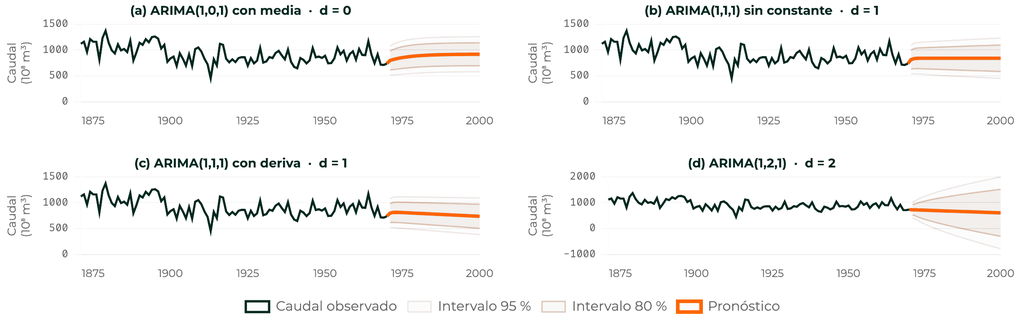

Pronóstico a 30 años del Nilo, con intervalo al 95 %, según el modelo. Simulador del Módulo 9

`Interpretación` Los coeficientes ARMA gobiernan los primeros pasos; a largo plazo solo quedan \(d\) y la constante.

Contexto: el Nilo; los cuatro modelos de la tabla siguiente. Fuente: J `nilo.formas_pronostico` · simulador del Módulo 9

Capítulo 4 · Modelos ARIMA y Box–JenkinsSeries de Tiempo · UnBosque37 / 50

Módulos 8–9 · Diagnóstico y pronóstico

## Con \(d=2\) el intervalo a 30 años es 3.5 veces más ancho, y aquí no se justifica

| Modelo (Nilo) | Forma a largo plazo | \(\nabla\hat y\) en \(h=30\) | Ancho 95 %, \(h=1\to30\) |
| --- | --- | --- | --- |
| ARIMA(1,0,1) con media | Vuelve a la media | 0.25, tiende a 0 | 561 → 677 |
| ARIMA(1,1,1) sin constante | **Constante** en el último nivel | 0.00 | 557 → 781 |
| ARIMA(1,1,1) con deriva | **Recta** de pendiente \(\hat\delta\) | −2.88 | 555 → 708 |
| ARIMA(1,2,1) | **Recta**, no parábola | −4.05 | 613 → **2771** |

`Interpretación` Un intervalo más ancho no delata por sí solo un \(d\) equivocado: es el precio de imponer una raíz más. Aquí no se justifica: el ARIMA(1,2,1) tiene \(\hat\theta=-1\), el modelo sobrediferenciado del Módulo 8.

Contexto: el Nilo, pronóstico a 30 años; ilustra que \(d\) y la constante fijan la forma. Fuente: J `nilo.formas_pronostico`, `nilo.intervalos.forma_medida` · R

Capítulo 4 · Modelos ARIMA y Box–JenkinsSeries de Tiempo · UnBosque38 / 50

Módulos 8–9 · Diagnóstico y pronóstico

## El ancho del intervalo sale de los pesos ψ de la representación MA(∞)

$$\sigma_h^2=\sigma^2\sum_{j=0}^{h-1}\psi_j^2,\qquad \hat y_{T+h\mid T}\pm z_{1-\alpha/2}\,\sigma_h$$

En el ARIMA(1,1,1): \(\psi_j=\dfrac{(1+\theta)-(\phi+\theta)\,\phi^{\,j}}{1-\phi}\to\psi_\infty=\dfrac{1+\theta}{1-\phi}\)

- `Definición` \(\psi_0=1\): a un paso el intervalo lo fija solo \(\sigma\). Como \(\psi_j^2\ge0\), \(\sigma_h\) **nunca decrece** con el horizonte
- `Definición` Con \(d=1\), \(\psi_j\) tiende a una constante y \(\sigma_h\) crece como \(\sqrt h\); con \(d=2\), como \(h^{3/2}\), salvo que \(\theta(1)=0\): una raíz unitaria en el MA cancela una diferencia
- `Dato` En el Nilo, \(\psi_\infty=0.1688\); con estos pesos se reconstruyen los intervalos de `forecast()` con un error máximo del orden de \(10^{-10}\)

Contexto: el Nilo, ARIMA(1,1,1). Fuente: J `nilo.intervalos` · R regenerado · C Módulo 9

Capítulo 4 · Modelos ARIMA y Box–JenkinsSeries de Tiempo · UnBosque39 / 50

Módulos 8–9 · Diagnóstico y pronóstico

## A 30 años, la incertidumbre del Nilo es casi cuatro veces menor que la de una caminata

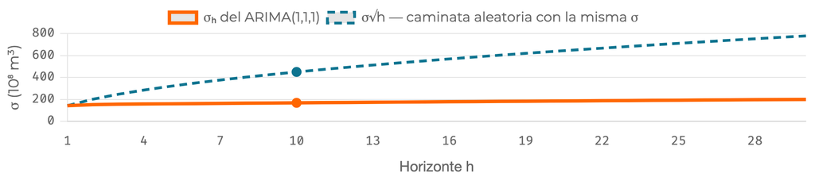

Desviación del error del ARIMA(1,1,1) frente a σ√h, la caminata aleatoria con la misma σ. Simulador del Módulo 9 (h = 10)

| Serie, ARIMA(1,1,1) | \(\psi_\infty\) | \(\sigma_h\) frente a la caminata |
| --- | --- | --- |
| **Nilo** | 0.169 | \(\sigma_{30}=199.4\) frente a 778.0: casi 4 veces menos |
| **BJsales** | 2.99 | \(\sigma_{12}\) es 1.96 veces el de una caminata |

`Interpretación` Con \(\hat\theta=-0.874\) el MA cancela casi toda la integración: los choques casi no se acumulan. En BJsales ocurre lo contrario.

Contexto: BJsales (\(n=150\)) es el ejercicio 3, como contraste. Fuente: J `nilo.intervalos` · R sobre `BJsales`

Capítulo 4 · Modelos ARIMA y Box–JenkinsSeries de Tiempo · UnBosque40 / 50

Universidad El Bosque

Series de Tiempo

Capítulo 4 · Modelos ARIMA y Box–Jenkins

Módulos 1–2 · El modelo y el método

Módulos 3–4 · Elegir d, p y q

Módulos 5–7 · Constante, estimación y auto.arima

Módulos 8–9 · Diagnóstico y pronóstico

Módulo 10 · Caso TRM, puente y cierre

05

## Módulo 10 · Caso TRM, puente y cierre

Nueve módulos desmontaron el ciclo sobre el Nilo. Ahora, de un tirón, sobre una serie que no se eligió por dócil.

Leer en el material: Caso TRM, puente y cierre

41 / 50

Módulo 10 · Caso TRM, puente y cierre

## Sobre la TRM, las cuatro pruebas dicen d = 1

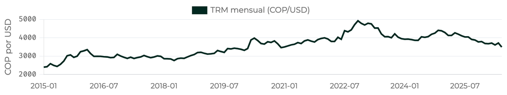

TRM mensual, enero 2015–junio 2026 (COP por USD), n = 138. Simulador del Módulo 10

|  | Sin diferenciar | Diferenciada una vez |
| --- | --- | --- |
| ADF | −1.978 (\(p=0.585\)): no rechaza | −3.880 (\(p=0.017\)): rechaza |
| KPSS | 2.243 (\(p<0.01\)): rechaza | 0.241 (\(p>0.10\)): no rechaza |

- `Dato` `nsdiffs` = 0. En la ACF de ∇TRM, \(\hat\rho_1=0.088\) y una sola barra fuera de ±0.167 (\(\hat\rho_8=-0.190\)), aislada y sin patrón
- `Interpretación` ∇TRM parece ruido blanco: la tabla del Capítulo 3 propone \(p=q=0\)

Contexto: TRM, copia congelada (2026-07-26) [SIN VERIFICAR] frente a datos.gov.co. Fuente: J `trm.pruebas`, `trm.identificacion` · R

Capítulo 4 · Modelos ARIMA y Box–JenkinsSeries de Tiempo · UnBosque42 / 50

Módulo 10 · Caso TRM, puente y cierre

## El mínimo de AICc es un modelo degenerado, y `auto.arima` elige la caminata aleatoria

- `Dato` Rejilla: mínimo de AICc, el ARIMA(2,1,2) con **1703.38** (gana por 2.56 puntos); mínimo de BIC, el ARIMA(0,1,0) con **1708.83**
- `Dato` Raíces del (2,1,2): AR en **1.0042** y MA en **1.0000**: no es invertible
- `Dato` `auto.arima`, búsqueda exhaustiva sobre **192** modelos (150 con parte estacional, 42 sin ella): ARIMA(0,1,0)
- `Dato` Ljung–Box(20): \(p=0.189\); Ljung–Box(12): \(p=0.206\). Shapiro–Wilk: \(p=0.0006\), los residuales **no** son normales
- `Dato` Con deriva: \(\hat\delta=8.00\) pesos/mes (e.e. 10.36; \(t=0.77\)), no significativa
- `Interpretación` La TRM es compatible con una caminata aleatoria

Contexto: la TRM; el (2,1,2) gana por un espejismo numérico. Fuente: J `trm.mejor_aicc`, `trm.minimo_degenerado`, `trm.auto_arima`, `trm.caminata`, `trm.deriva` · R regenerado

Capítulo 4 · Modelos ARIMA y Box–JenkinsSeries de Tiempo · UnBosque43 / 50

Opinión

## El diagnóstico manda sobre el criterio

Un AICc mínimo con una raíz sobre el círculo unitario no es el mejor modelo, es un espejismo numérico. Antes de creer en el criterio: las raíces, Ljung–Box y la ACF de los residuales.

Contexto: el (2,1,2) de la TRM y el (1,2,2) del Nilo (Módulos 6 y 10). Fuente: C Módulos 6 y 10

Capítulo 4 · Modelos ARIMA y Box–JenkinsSeries de Tiempo · UnBosque44 / 50

Módulo 10 · Caso TRM, puente y cierre

## A dos años, el intervalo del 95 % se extiende un tercio del nivel hacia cada lado

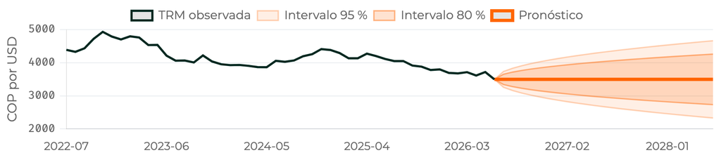

TRM y pronóstico de caminata aleatoria, con intervalos al 80 % y 95 %. Simulador del Módulo 10

| \(h\) | Mes | Semiancho al 95 % | Intervalo | Semiancho sobre el nivel |
| --- | --- | --- | --- | --- |
| 1 | jul 2026 | ±238.09 | [3259.00, 3735.18] | 6.8 % |
| 12 | jun 2027 | ±824.76 | [2672.33, 4321.85] | 23.6 % |
| 24 | jun 2028 | ±1166.39 | [2330.70, 4663.48] | 33.4 % |

`Interpretación` A ese horizonte no hay nada que decir: un pronóstico honesto puede ser inútil. Y aun así es optimista: no incluye la incertidumbre de estimar ni de elegir el modelo

Contexto: TRM, ARIMA(0,1,0) sin deriva; último dato jun 2026 = 3497.09; \(\hat\sigma_h=121.48\sqrt h\). Fuente: J `trm.caminata` · R

Capítulo 4 · Modelos ARIMA y Box–JenkinsSeries de Tiempo · UnBosque45 / 50

Opinión

## «No hay señal» es un resultado, no un fracaso

El intervalo a dos años lo muestra: un pronóstico honesto puede ser inútil. Un modelo que dice que no hay nada que decir ha hecho su trabajo, y es la referencia que el Capítulo 6 enseña a batir.

Contexto: cierra el caso de la TRM. Fuente: C Módulo 10, «Lo que hay que llevarse»

Capítulo 4 · Modelos ARIMA y Box–JenkinsSeries de Tiempo · UnBosque46 / 50

Pregunta para la clase

## Residuales del mejor ARIMA no estacional en log(AirPassengers): ¿qué se concluye?

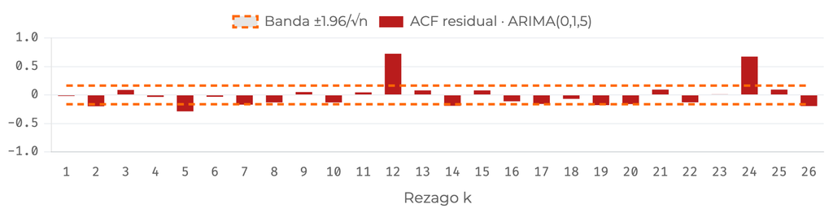

ACF de los residuales del mejor ARIMA no estacional sobre log(AirPassengers). Simulador del Módulo 10

Los rezagos 12 y 24 se disparan: \(\hat\rho_{12}=0.7245\) y \(\hat\rho_{24}=0.6727\), con banda ±0.1633.

Hace falta un modelo estacional

`Interpretación` El patrón está en los múltiplos de 12: subir \(p\) o \(q\) no lo arregla; hace falta SARIMA.

Contexto: `AirPassengers` en log (\(n=144\)), mensual y con estacionalidad evidente. Fuente: J `puente_estacional` · R regenerado

Capítulo 4 · Modelos ARIMA y Box–JenkinsSeries de Tiempo · UnBosque47 / 50

Módulo 10 · Caso TRM, puente y cierre

## El *airline* resuelve con dos parámetros lo que el ARIMA(0,1,5) no logra con cinco

- `Dato` El mejor no estacional con \(p+q\le5\), el tope por defecto de `auto.arima`, es un ARIMA(0,1,5): Ljung–Box(24): \(Q=222.4\), \(p<10^{-6}\)
- `Dato` El *airline*, ARIMA(0,1,1)(0,1,1)\(_{12}\), con dos parámetros: \(\hat\rho_{12}=-0.0515\); Ljung–Box(24): \(p=0.233\)

Los AICc no se comparan

El no estacional usa 143 observaciones efectivas; el *airline*, 131. Decide el **diagnóstico**.

Contexto: `AirPassengers` en log (\(n=144\)), mensual y con estacionalidad evidente. Fuente: J `puente_estacional` · R regenerado

Capítulo 4 · Modelos ARIMA y Box–JenkinsSeries de Tiempo · UnBosque48 / 50

Módulo 10 · Caso TRM, puente y cierre

## Lo que se llevan hoy

- Un ARIMA(\(p,d,q\)) es un ARMA(\(p+d,q\)) con \(d\) raíces unitarias: la diferenciación es **parte del modelo**
- \(d\) se elige con tres evidencias —gráfico, varianza y pruebas—, y las pruebas **pueden engañar**: KPSS confunde un escalón con una raíz unitaria
- El AICc **no** es comparable entre distintos \(d\): se agrupa por \(d\)
- El **diagnóstico manda** sobre el criterio (raíces, Ljung–Box y ACF residual), y «no hay señal» es un resultado, no un fracaso
- \(d\) y la constante deciden la forma del pronóstico; con \(d=1\) el intervalo crece como \(\sqrt h\), sin techo

Javier Mauricio Sierra

Capítulo 4 · Modelos ARIMA y Box–JenkinsSeries de Tiempo · UnBosque49 / 50

Módulo 10 · Caso TRM, puente y cierre

## Para seguir: tres ejercicios y el simulacro del quiz

### Ejercicios propuestos

1. **BJsales**: recorre el ciclo. ¿Sobrevive el IMA(1,1) «de libro» al diagnóstico?
2. **log(lynx)**: ¿hay que diferenciarla? Si la varianza y las pruebas discrepan, decide con las raíces
3. **El intervalo a mano**: construye el de BJsales desde los pesos \(\psi\) y compáralo con `forecast()`

### Antes de la próxima sesión

- **Módulo 11** del material: el simulacro del quiz del capítulo 3 y los módulos 4.1–4.4, con reloj y sin clave
- **Lecturas** del capítulo: Módulo 10, sección «Lecturas»

Informe de verificación, cifra por cifra: [verificacion_cifras.md en GitHub](https://github.com/JotaMao1985/Series-de-Tiempo_Un_Bosque/blob/main/Htmls_Series/diapositivas/fuentes/verificacion/verificacion_cifras.md)

Capítulo 4 · Modelos ARIMA y Box–JenkinsSeries de Tiempo · UnBosque50 / 50

[output not shown]

·

00:00

A continuación

Notas